# Biological QA after resequencing of all the batches

Thomas Dobrenel and Nicolas Delhomme

2019-12-03

# 1 Setup

Set the working dir

```r
setwd("/mnt/picea/projects/arabidopsis/jhanson/arabidopsis-nutrition-TOR/all-batches")
```

Load libraries

```r
suppressPackageStartupMessages({
    library(data.table)
    library(DESeq2)
    library(gplots)
    library(here)
    library(hyperSpec)
    library(limma)
    library(parallel)
    library(pander)
    library(plotly)
    library(RColorBrewer)
    library(scatterplot3d)
    library(tidyverse)
    library(tximport)
    library(vsn)
})
```

Source some helper functions

```r
source("~/Git/UPSCb/UPSCb-common/src/R/plot.multidensity.R")
source("~/Git/UPSCb/UPSCb-common/src/R/featureSelection.R")
```

Create palettes

```r
pal <- c(brewer.pal(8,"Dark2"),1)
cols <- rainbow(17)
hpal <- colorRampPalette(c("blue","white","red"))(100)
```

Register the default plot margin

```r
mar <- par("mar")
```

# 2 Raw data

## 2.1 Loading

Read the sample information

```r
samples <- read.csv("~/Git/UPSCb/projects/arabidopsis-nutrition-TOR/doc/samples3.csv")
samples <- read.csv("~/Git/UPSCb/projects/arabidopsis-nutrition-TOR/doc/samples4.csv")

# The data

filenames <- list.files("../Salmon",
                    recursive = TRUE,
                    pattern = "quant.sf",
                    full.names = TRUE)
```

name them

```r
names(filenames) <- sub("_S.*","",sapply(strsplit(filenames, "/"), .subset, 3))
```

Reorder the sample data.frame according to the way the results were read in and accounting for tech reps

```r
samples <- samples[match(names(filenames),samples$SciLifeID),]
samples$Conditions <- factor(paste(samples$Timepoint,samples$Nutrition,samples$AZD,sep="_"))
samples$Batch <- factor(substr(samples$SciLifeID,1,8))
```

Read the expression at the transcript level

```r
tx <- suppressMessages(tximport(files = filenames,
                                type = "salmon",
                                txOut = TRUE))
```

summarise to genes

```r
tx2gene <- data.frame(TXID=rownames(tx$counts),
                      GENEID=sub("\\.[0-9]+","",rownames(tx$counts)))
gx <- summarizeToGene(tx,tx2gene=tx2gene)
```

```
## summarizing abundance
```

```
## summarizing counts
```

```
## summarizing length
```

```r
kg <- round(gx$counts)
```

Sanity check

```r
stopifnot(all(colnames(kg) == samples$SciLifeID))
```

## 2.2 Raw data export

```r
#dir.create(file.path("analysis_Tom","salmon"),showWarnings=FALSE,recursive=TRUE)
#write.table(kg,file="/mnt/picea/projects/arabidopsis/jhanson/arabidopsis-nutrition-TOR/analysis_Tom/nutrition-unormalised-gene-expression_data.csv")
#save(kg, samples, file = "/mnt/picea/projects/arabidopsis/jhanson/arabidopsis-nutrition-TOR/analysis_Tom/counts.rda")
```

## 2.3 Preliminary validations

### 2.3.1 Check for the genes that are never expressed

```r
sel <- rowSums(kg) == 0
sprintf("%s%% (%s) of %s genes are not expressed",
        round(sum(sel) * 100/ nrow(kg),digits=1),
        sum(sel),
        nrow(kg))
```

```
## [1] "15.6% (5043) of 32310 genes are not expressed"
```

### 2.3.2 Display the samples mean raw counts distribution

i.e. the mean raw count of every gene across samples is calculated and displayed on a log10 scale.

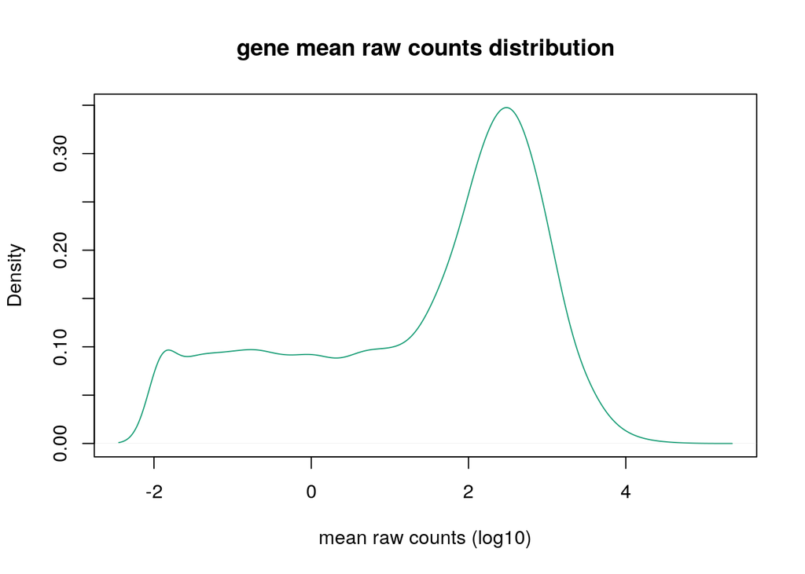

```r
plot(density(log10(rowMeans(kg))),col=pal[1],
     main="gene mean raw counts distribution",
     xlab="mean raw counts (log10)")
```

### 2.3.3 Display all samples raw counts distribution

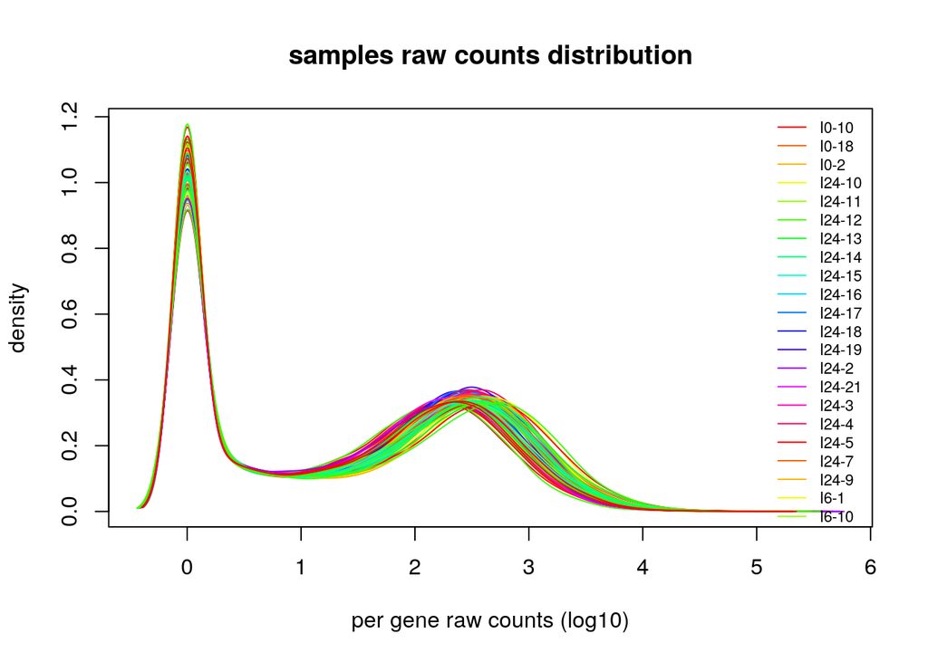

```r
plot.multidensity(log10(kg+1),
                  col=cols[as.integer(samples$Conditions)],
                  legend.x="topright",
                  legend=levels(samples$SampleName),
                  legend.col=cols,
                  legend.lwd=1,legend.cex=.7,
                  main="samples raw counts distribution",
                  xlab="per gene raw counts (log10)")
```

# 3 Data normalisation

For visualization, the data is submitted to a variance stabilization transformation using DESeq2. The dispersion is estimated independently of the sample type

```r
dds <- DESeqDataSetFromMatrix(
    countData = kg,
    colData = samples,
    design = ~ Conditions)
```

Check the size factors (i.e. the sequencing library size effect) There is no big variation, a Variance Stabilizing Transformation can be used (over a Relative Log Transformation)

```r
dds <- estimateSizeFactors(dds)
sizes <- sizeFactors(dds)
names(sizes) <- colnames(kg)
sizes
```

```
## P11554_138 P11554_139 P11554_140 P11554_141 P11554_142 P11554_143 P11554_144
##  0.6536383  0.5977196  0.6994577  1.1735839  0.7877462  0.8721788  0.8576147
## P11554_145 P11554_146 P11554_147 P11554_148 P11554_149 P11554_150 P11554_151
##  0.5766411  0.9610835  0.8888235  0.6930760  1.0758807  1.1153752  0.8588927
## P11554_152 P11554_153 P11554_154 P11554_155 P11554_202 P11554_203 P11554_204
##  0.8167666  0.8141068  0.8586574  0.8863683  0.6584734  0.8540868  0.6946303
## P11554_205 P11554_206 P11554_207 P11554_208 P11554_209 P11554_210 P11554_211
##  0.8603203  0.9488507  1.2299634  1.0349373  0.8652596  0.9310604  1.3725176
## P11554_212 P11554_213 P11554_214 P11554_215 P11554_216 P11554_217 P11554_218
##  1.1039265  0.9593232  1.1469385  1.0888817  1.0678946  1.1311996  1.2279160
## P11554_219 P11554_220 P11554_221 P11554_222 P11554_223 P11554_224 P11554_225
##  1.4542231  1.1082138  1.2260732  1.3341166  1.0484505  1.1272136  0.7083859
## P11554_226 P11554_227 P11554_228 P11554_229 P11554_230 P11554_231 P11554_232
##  1.0534835  1.0900091  1.2733347  0.7280416  0.8867898  0.9086385  0.7607187
## P11554_233 P11554_234 P11554_235 P11554_236 P11554_237 P13406_101 P13406_102
##  0.7871034  1.3643028  1.6068273  1.3584109  1.1784454  1.5931178  1.4499206
## P13406_103 P13406_104 P13406_105 P13406_106 P14066_128 P14066_131 P14066_133
##  1.2323704  1.4214448  1.0815197  1.1860909  1.1825912  0.9771133  1.0738076
## P14066_139 P14066_140 P14066_141 P14066_142 P14066_143 P14066_144 P14066_145
##  0.8589182  1.0650880  1.0131169  1.1278433  1.1293723  1.0409047  0.9042735
## P14066_146 P14066_147 P14066_148 P14066_149 P14066_152 P14066_153 P14066_154
##  1.2838911  1.0692348  1.1210901  0.8016672  1.2401557  1.6835673  0.9614065
## P14066_156 P14066_157
##  0.8424498  0.7430140
```

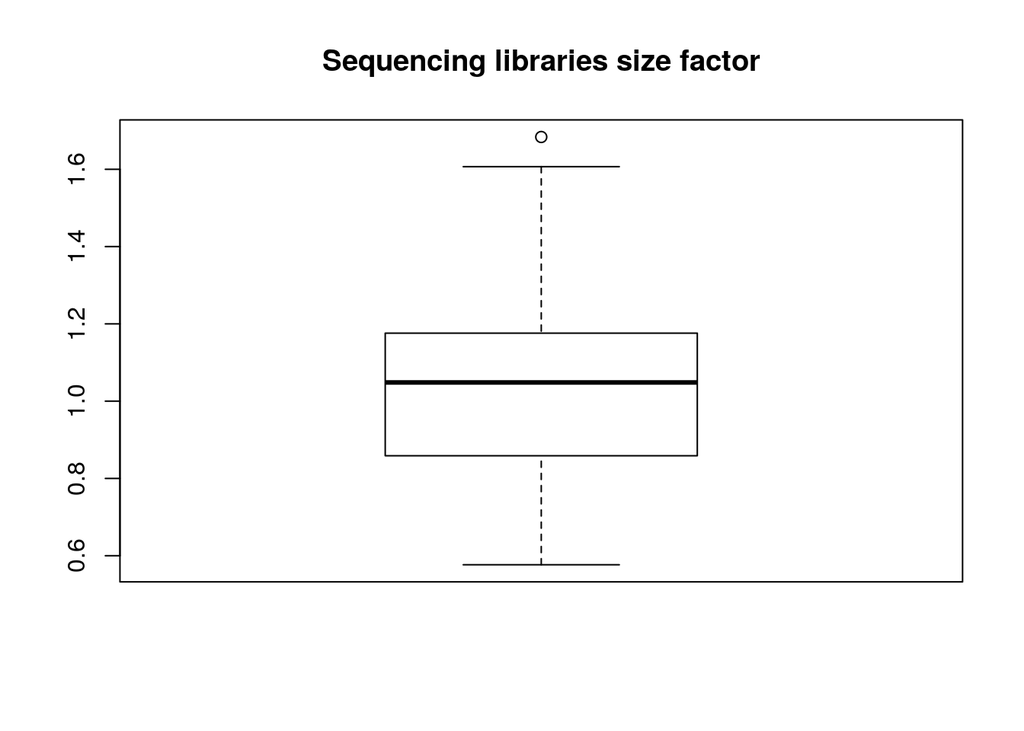

```r
boxplot(sizes, main="Sequencing libraries size factor")
```

split by batch effect

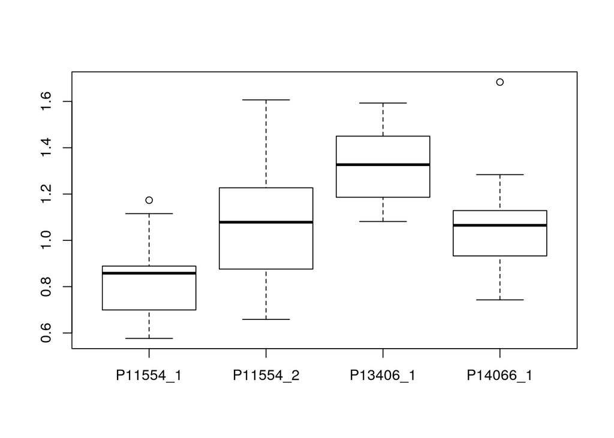

```r
boxplot(split(sizes,samples$Batch))
```

## 3.1 VST

```r
vsd <- varianceStabilizingTransformation(dds, blind=TRUE)
vst <- assay(vsd)
vst <- vst - min(vst)
```

Validation

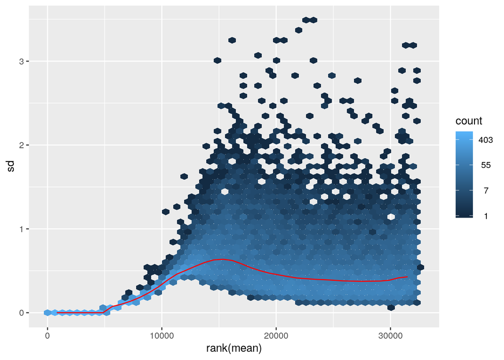

```r
meanSdPlot(vst)
```

Write out

```r
#write.csv(vst,"/mnt/picea/projects/arabidopsis/jhanson/arabidopsis-nutrition-TOR/analysis_Tom/library-size-normalized_variance-stabilized_data_nutrition.csv")
```

## 3.2 Biological QA

### 3.2.1 MDS

Verification of the sample distribution by a multivariate approach on the raw data

- Samples

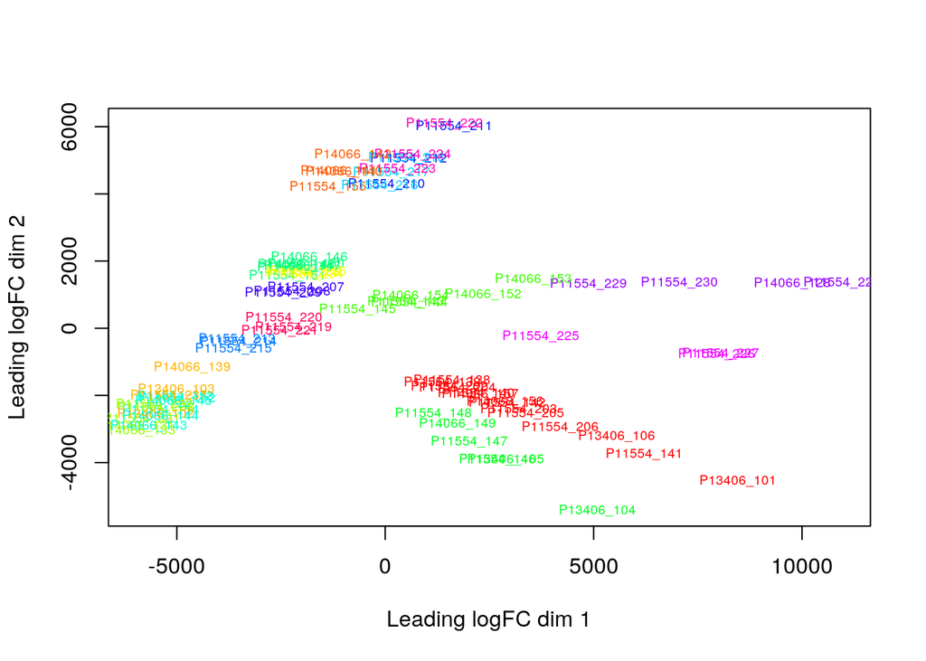

```r
plotMDS(kg,cex=.6,col=cols[as.integer(samples$Conditions)])
```

- Suspect samples

```r
suspect <- c("P11554_155","P11554_237","P13406_105")
sel <- samples$Conditions %in% samples[match(suspect,samples$SciLifeID),"Conditions"]
pander(samples[sel,])
```

Table continues below

|  | SciLifeID | SampleName | Timepoint | Nutrition | AZD | Conditions |
| --- | --- | --- | --- | --- | --- | --- |
| **93** | P11554_146 | I24-21 | 24 | NS | DMSO | 24_NS_DMSO |
| **94** | P11554_147 | J24-20 | 24 | NS | DMSO | 24_NS_DMSO |
| **95** | P11554_148 | I24-19 | 24 | NS | DMSO | 24_NS_DMSO |
| **102** | P11554_155 | I24-12 | 24 | NP | AZD | 24_NP_AZD |
| **37** | P11554_237 | I24-7 | 24 | NP | DMSO | 24_NP_DMSO |
| **61** | P13406_102 | I24-7 | 24 | NP | DMSO | 24_NP_DMSO |
| **62** | P13406_103 | J24-8 | 24 | NP | DMSO | 24_NP_DMSO |
| **63** | P13406_104 | J24-20 | 24 | NS | DMSO | 24_NS_DMSO |
| **64** | P13406_105 | I24-21 | 24 | NS | DMSO | 24_NS_DMSO |
| **69** | P14066_139 | I24-9 | 24 | NP | DMSO | 24_NP_DMSO |
| **70** | P14066_140 | I24-10 | 24 | NP | AZD | 24_NP_AZD |
| **71** | P14066_141 | I24-11 | 24 | NP | AZD | 24_NP_AZD |
| **72** | P14066_142 | I24-12 | 24 | NP | AZD | 24_NP_AZD |
| **79** | P14066_149 | I24-19 | 24 | NS | DMSO | 24_NS_DMSO |

|  | Batch |
| --- | --- |
| **93** | P11554_1 |
| **94** | P11554_1 |
| **95** | P11554_1 |
| **102** | P11554_1 |
| **37** | P11554_2 |
| **61** | P13406_1 |
| **62** | P13406_1 |
| **63** | P13406_1 |
| **64** | P13406_1 |
| **69** | P14066_1 |
| **70** | P14066_1 |
| **71** | P14066_1 |
| **72** | P14066_1 |
| **79** | P14066_1 |

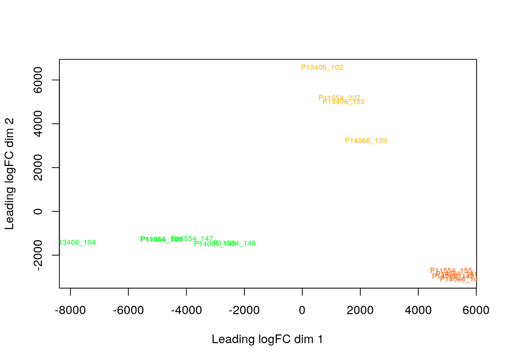

```r
plotMDS(kg[,sel],cex=.6,col=cols[as.integer(samples$Conditions)][sel])
```

- Suspect Batch

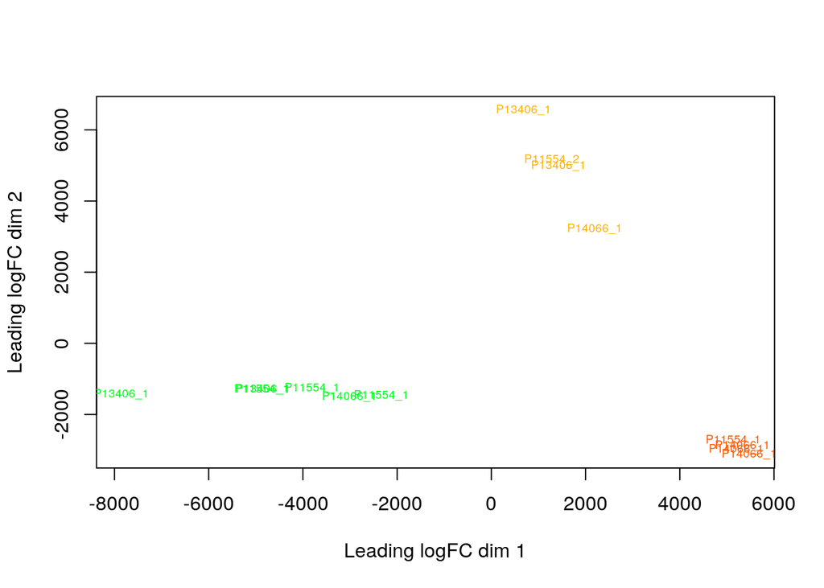

```r
plotMDS(kg[,sel],cex=.6,labels=samples$Batch[sel],col=cols[as.integer(samples$Conditions)][sel])
```

### 3.2.2 PCA

Principal Component Analysis on the normalized data

- Colour coded by Nutrition and AZD treatment - all data

```r
conditions1 <- factor(paste(samples$AZD,samples$Nutrition,sep="_"))
pch<-as.integer(factor(samples$Timepoint))+14
pc <- prcomp(t(vst))
percent <- round(summary(pc)$importance[2,]*100);percent
```

```
##  PC1  PC2  PC3  PC4  PC5  PC6  PC7  PC8  PC9 PC10 PC11 PC12 PC13 PC14 PC15 PC16
##   37   20   14    6    3    2    2    1    1    1    1    0    0    0    0    0
## PC17 PC18 PC19 PC20 PC21 PC22 PC23 PC24 PC25 PC26 PC27 PC28 PC29 PC30 PC31 PC32
##    0    0    0    0    0    0    0    0    0    0    0    0    0    0    0    0
## PC33 PC34 PC35 PC36 PC37 PC38 PC39 PC40 PC41 PC42 PC43 PC44 PC45 PC46 PC47 PC48
##    0    0    0    0    0    0    0    0    0    0    0    0    0    0    0    0
## PC49 PC50 PC51 PC52 PC53 PC54 PC55 PC56 PC57 PC58 PC59 PC60 PC61 PC62 PC63 PC64
##    0    0    0    0    0    0    0    0    0    0    0    0    0    0    0    0
## PC65 PC66 PC67 PC68 PC69 PC70 PC71 PC72 PC73 PC74 PC75 PC76 PC77 PC78 PC79
##    0    0    0    0    0    0    0    0    0    0    0    0    0    0    0
```

- 0 hours

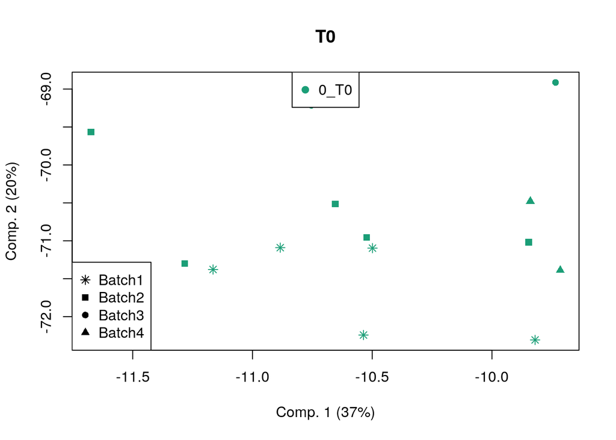

```r
t.sel <- samples$Timepoint == 0
conds <- droplevels(conditions1[t.sel])
plot(pc$x[t.sel,1],
     pc$x[t.sel,2],
     xlab=paste("Comp. 1 (",percent[1],"%)",sep=""),
     ylab=paste("Comp. 2 (",percent[2],"%)",sep=""),
     col=pal[as.integer(conds)],
     pch=c(8,15,16,17)[as.integer(samples$Batch)[t.sel]],
     main="T0")

legend("top",pch=19,
       col=pal[1:nlevels(conds)],
       legend=levels(conds))

legend("bottomleft",pch=c(8,15,16,17),
       col="black",
       legend=c("Batch1","Batch2","Batch3","Batch4"))
```

- 6 hours

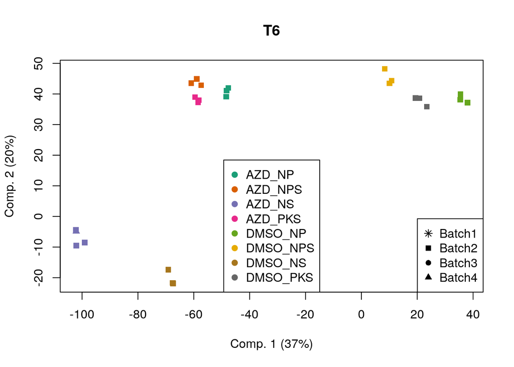

```r
t.sel <- samples$Timepoint == 6
conds <- droplevels(conditions1[t.sel])
plot(pc$x[t.sel,1],
     pc$x[t.sel,2],
     xlab=paste("Comp. 1 (",percent[1],"%)",sep=""),
     ylab=paste("Comp. 2 (",percent[2],"%)",sep=""),
     col=pal[as.integer(conds)],
     pch=c(8,15,16,17)[as.integer(samples$Batch)[t.sel]],
     main="T6")

legend("bottom",pch=19,
       col=pal[1:nlevels(conds)],
       legend=levels(conds))

legend("bottomright",pch=c(8,15,16,17),
       col="black",
       legend=c("Batch1","Batch2","Batch3","Batch4"))
```

- 24 hours

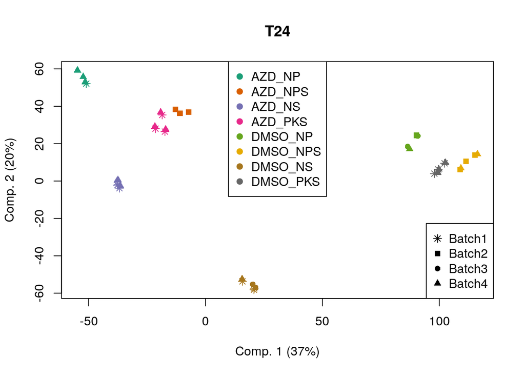

```r
t.sel <- samples$Timepoint == 24
conds <- droplevels(conditions1[t.sel])
plot(pc$x[t.sel,1],
     pc$x[t.sel,2],
     xlab=paste("Comp. 1 (",percent[1],"%)",sep=""),
     ylab=paste("Comp. 2 (",percent[2],"%)",sep=""),
     col=pal[as.integer(conds)],
     pch=c(8,15,16,17)[as.integer(samples$Batch)[t.sel]],
     main="T24")

legend("top",pch=19,
       col=pal[1:nlevels(conds)],
       legend=levels(conds))

legend("bottomright",pch=c(8,15,16,17),
       col="black",
       legend=c("Batch1","Batch2","Batch3","Batch4"))
```

- 24 hours or 0 hrs

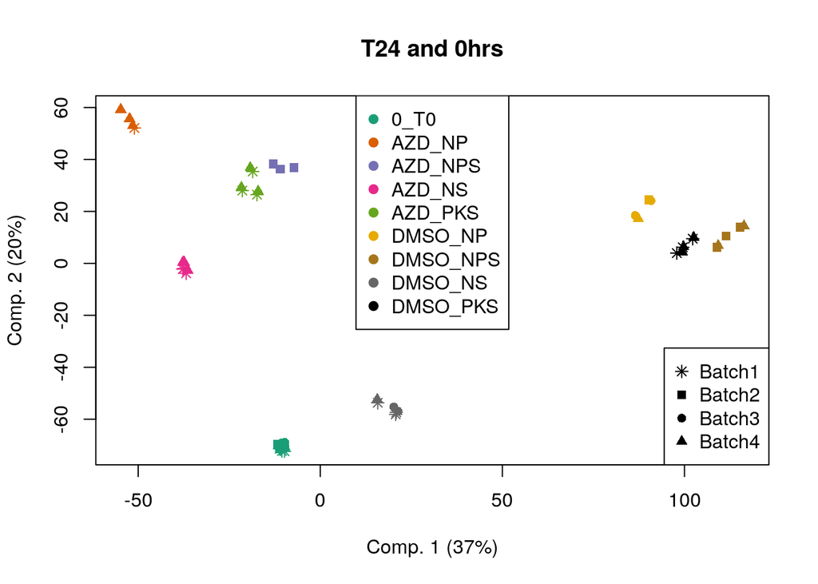

```r
t.sel <- samples$Timepoint %in% c(0,24)
conds <- droplevels(conditions1[t.sel])
plot(pc$x[t.sel,1],
     pc$x[t.sel,2],
     xlab=paste("Comp. 1 (",percent[1],"%)",sep=""),
     ylab=paste("Comp. 2 (",percent[2],"%)",sep=""),
     col=pal[as.integer(conds)],
     pch=c(8,15,16,17)[as.integer(samples$Batch)[t.sel]],
     main="T24 and 0hrs")

legend("top",pch=19,
       col=pal[1:nlevels(conds)],
       legend=levels(conds))

legend("bottomright",pch=c(8,15,16,17),
       col="black",
       legend=c("Batch1","Batch2","Batch3","Batch4"))
```

- All timepoints

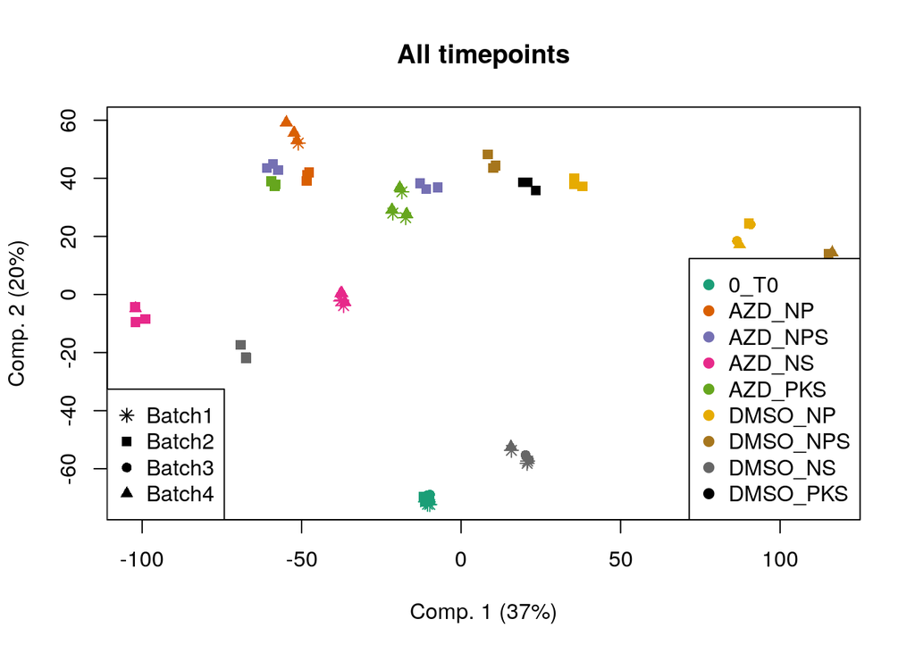

```r
t.sel <- samples$Timepoint %in% c(0,6,24)
conds <- droplevels(conditions1[t.sel])
plot(pc$x[t.sel,1],
     pc$x[t.sel,2],
     xlab=paste("Comp. 1 (",percent[1],"%)",sep=""),
     ylab=paste("Comp. 2 (",percent[2],"%)",sep=""),
     col=pal[as.integer(conds)],
     pch=c(8,15,16,17)[as.integer(samples$Batch)[t.sel]],
     main="All timepoints")

legend("bottomright",pch=19,
       col=pal[1:nlevels(conds)],
       legend=levels(conds))

legend("bottomleft",pch=c(8,15,16,17),
       col="black",
       legend=c("Batch1","Batch2","Batch3","Batch4"))
```

- Batch 2, 3 and 4 only

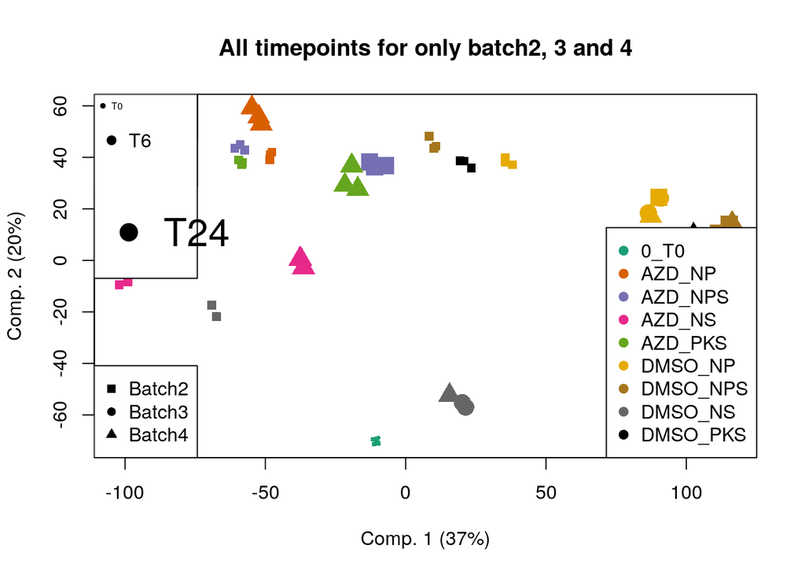

```r
t.sel <- samples$Batch %in% c("P11554_2","P13406_1", "P14066_1")
conds <- droplevels(conditions1[t.sel])
plot(pc$x[t.sel,1],
     pc$x[t.sel,2],
     xlab=paste("Comp. 1 (",percent[1],"%)",sep=""),
     ylab=paste("Comp. 2 (",percent[2],"%)",sep=""),
     col=pal[as.integer(conds)],
     pch=c(8,15,16,17)[as.integer(samples$Batch)[t.sel]],
     cex=c(0.5,1,2)[as.factor(samples$Timepoint)[t.sel]],
     main="All timepoints for only batch2, 3 and 4")


legend("bottomright",pch=19,
       col=pal[1:nlevels(conds)],
       legend=levels(conds))

legend("bottomleft",pch=c(15,16,17),
       col="black",
       legend=c("Batch2","Batch3","Batch4"))

legend("topleft",pch=19,
       cex=c(0.5,1,2),
       col="black",
       legend=c("T0","T6","T24"))
```

# 4 Heatmap

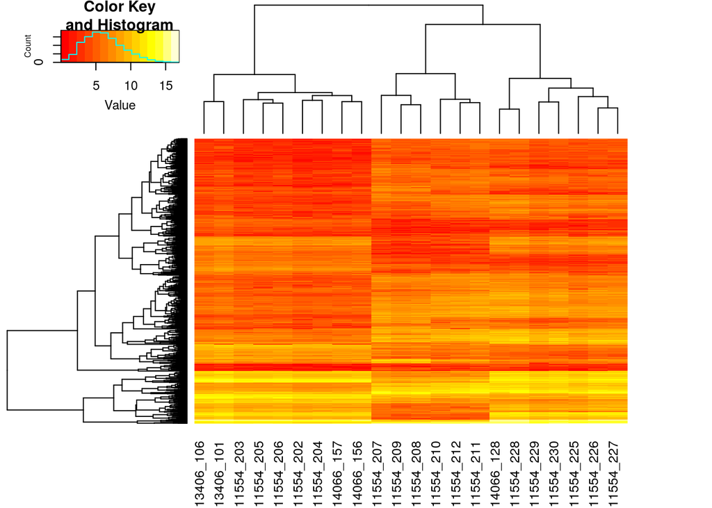

```r
ssel <- samples$SciLifeID[samples$Timepoint %in% c(0,6) &
                              samples$Nutrition %in% c("NPS","NS","T0") &
                              substr(colnames(tx$counts),1,8) %in% c("P11554_2","P13406_1","P14066_1")]
counts <- tx$counts[,substr(colnames(tx$counts),1,8) %in% c("P11554_2","P13406_1")]
counts <- tx$counts[,colnames(tx$counts) %in% factor(ssel)]
sel <- order(apply(log2(counts),1,sd),decreasing=TRUE)[1:1000]
heatmap.2(log2(counts[sel,]+1),labRow = NA,trace = "none")
```

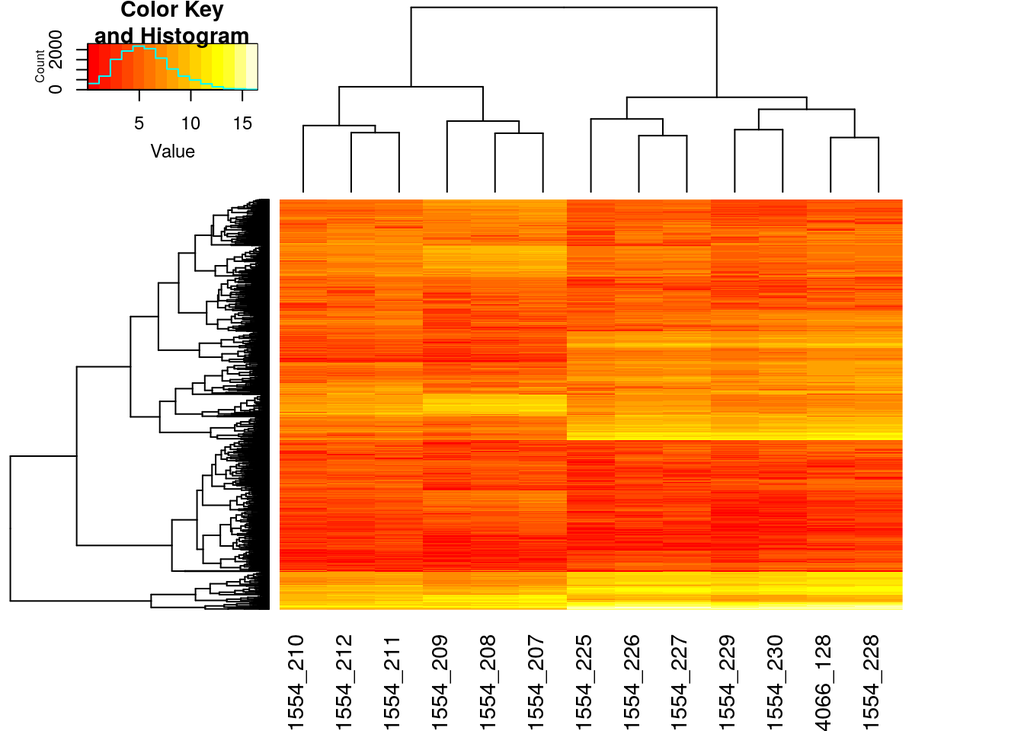

```r
ssel <- samples$SciLifeID[samples$Timepoint %in% c(0,6) &
                              samples$Nutrition %in% c("NPS","NS") &
                              substr(colnames(tx$counts),1,8) %in% c("P11554_2","P13406_1","P14066_1")]
counts <- tx$counts[,substr(colnames(tx$counts),1,8) %in% c("P11554_2","P13406_1")]
counts <- tx$counts[,colnames(tx$counts) %in% factor(ssel)]
sel <- order(apply(log2(counts),1,sd),decreasing=TRUE)[1:1000]
heatmap.2(log2(counts[sel,]+1),labRow = NA,trace = "none")
```

# 5 Selection of technical replicates

## 5.1 T0

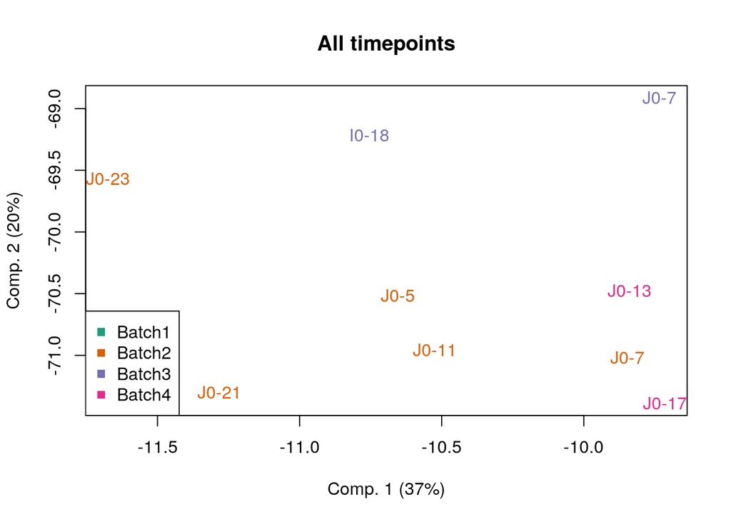

```r
t.sel <- samples$Timepoint == 0 & samples$Batch %in% c("P11554_2","P13406_1","P14066_1")
conds <- droplevels(conditions1[t.sel])
plot(pc$x[t.sel,1],
     pc$x[t.sel,2],
     xlab=paste("Comp. 1 (",percent[1],"%)",sep=""),
     ylab=paste("Comp. 2 (",percent[2],"%)",sep=""),
     type="n",
     main="All timepoints")

text(pc$x[t.sel,1],
     pc$x[t.sel,2],
     samples$SampleName[t.sel],
     col=pal[as.integer(samples$Batch)[t.sel]])

legend("bottomleft",col=pal[1:nlevels(samples$Batch)],
       pch=15,
       legend=c("Batch1","Batch2","Batch3","Batch4"))
```

```r
pander(samples[t.sel,][order(samples$SampleName[t.sel]),])
```

Table continues below

|  | SciLifeID | SampleName | Timepoint | Nutrition | AZD | Conditions |
| --- | --- | --- | --- | --- | --- | --- |
| **65** | P13406_106 | I0-18 | 0 | T0 | 0 | 0_T0_0 |
| **6** | P11554_206 | J0-11 | 0 | T0 | 0 | 0_T0_0 |
| **83** | P14066_156 | J0-13 | 0 | T0 | 0 | 0_T0_0 |
| **84** | P14066_157 | J0-17 | 0 | T0 | 0 | 0_T0_0 |
| **5** | P11554_205 | J0-21 | 0 | T0 | 0 | 0_T0_0 |
| **3** | P11554_203 | J0-23 | 0 | T0 | 0 | 0_T0_0 |
| **4** | P11554_204 | J0-5 | 0 | T0 | 0 | 0_T0_0 |
| **2** | P11554_202 | J0-7 | 0 | T0 | 0 | 0_T0_0 |
| **60** | P13406_101 | J0-7 | 0 | T0 | 0 | 0_T0_0 |

|  | Batch |
| --- | --- |
| **65** | P13406_1 |
| **6** | P11554_2 |
| **83** | P14066_1 |
| **84** | P14066_1 |
| **5** | P11554_2 |
| **3** | P11554_2 |
| **4** | P11554_2 |
| **2** | P11554_2 |
| **60** | P13406_1 |

## 5.2 T6

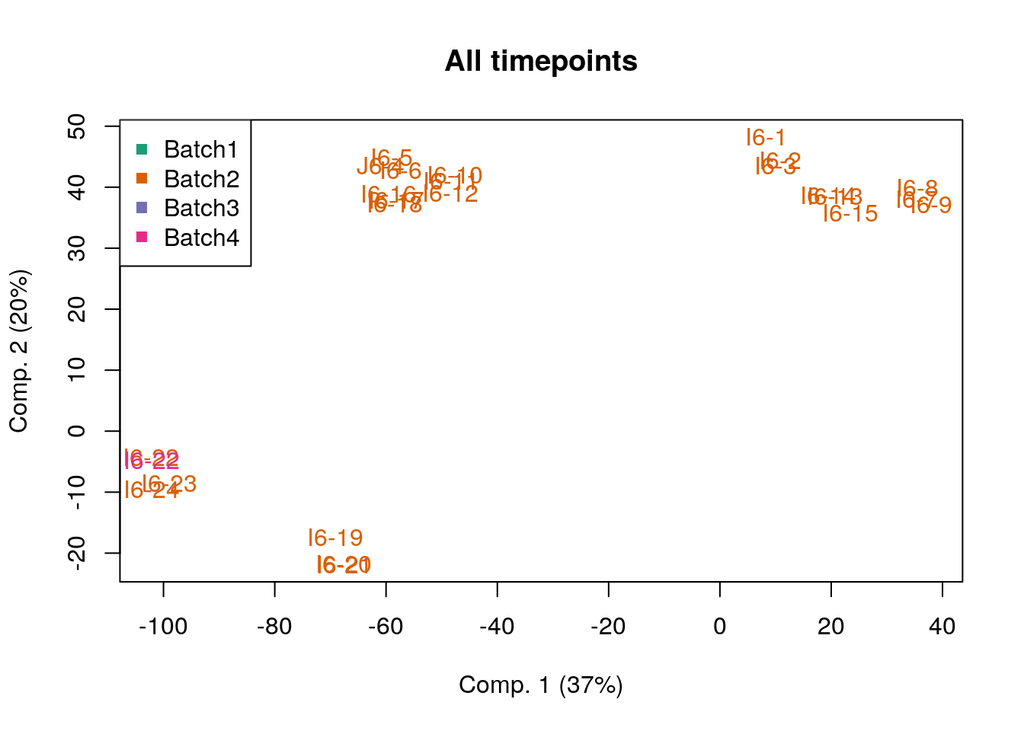

```r
t.sel <- samples$Timepoint == 6 & samples$Batch %in% c("P11554_2","P13406_1","P14066_1")
conds <- droplevels(conditions1[t.sel])
plot(pc$x[t.sel,1],
     pc$x[t.sel,2],
     xlab=paste("Comp. 1 (",percent[1],"%)",sep=""),
     ylab=paste("Comp. 2 (",percent[2],"%)",sep=""),
     type="n",
     main="All timepoints")

text(pc$x[t.sel,1],
     pc$x[t.sel,2],
     samples$SampleName[t.sel],
     col=pal[as.integer(samples$Batch)[t.sel]])

legend("topleft",col=pal[1:nlevels(samples$Batch)],
       pch=15,
       legend=c("Batch1","Batch2","Batch3","Batch4"))
```

```r
pander(samples[t.sel,][order(samples$SampleName[t.sel]),])
```

Table continues below

|  | SciLifeID | SampleName | Timepoint | Nutrition | AZD | Conditions |
| --- | --- | --- | --- | --- | --- | --- |
| **7** | P11554_207 | I6-1 | 6 | NPS | DMSO | 6_NPS_DMSO |
| **16** | P11554_216 | I6-10 | 6 | NP | AZD | 6_NP_AZD |
| **17** | P11554_217 | I6-11 | 6 | NP | AZD | 6_NP_AZD |
| **18** | P11554_218 | I6-12 | 6 | NP | AZD | 6_NP_AZD |
| **19** | P11554_219 | I6-13 | 6 | PKS | DMSO | 6_PKS_DMSO |
| **20** | P11554_220 | I6-14 | 6 | PKS | DMSO | 6_PKS_DMSO |
| **21** | P11554_221 | I6-15 | 6 | PKS | DMSO | 6_PKS_DMSO |
| **22** | P11554_222 | I6-16 | 6 | PKS | AZD | 6_PKS_AZD |
| **23** | P11554_223 | I6-17 | 6 | PKS | AZD | 6_PKS_AZD |
| **24** | P11554_224 | I6-18 | 6 | PKS | AZD | 6_PKS_AZD |
| **25** | P11554_225 | I6-19 | 6 | NS | DMSO | 6_NS_DMSO |
| **8** | P11554_208 | I6-2 | 6 | NPS | DMSO | 6_NPS_DMSO |
| **26** | P11554_226 | I6-20 | 6 | NS | DMSO | 6_NS_DMSO |
| **27** | P11554_227 | I6-21 | 6 | NS | DMSO | 6_NS_DMSO |
| **28** | P11554_228 | I6-22 | 6 | NS | AZD | 6_NS_AZD |
| **66** | P14066_128 | I6-22 | 6 | NS | AZD | 6_NS_AZD |
| **29** | P11554_229 | I6-23 | 6 | NS | AZD | 6_NS_AZD |
| **30** | P11554_230 | I6-24 | 6 | NS | AZD | 6_NS_AZD |
| **9** | P11554_209 | I6-3 | 6 | NPS | DMSO | 6_NPS_DMSO |
| **11** | P11554_211 | I6-5 | 6 | NPS | AZD | 6_NPS_AZD |
| **12** | P11554_212 | I6-6 | 6 | NPS | AZD | 6_NPS_AZD |
| **13** | P11554_213 | I6-7 | 6 | NP | DMSO | 6_NP_DMSO |
| **14** | P11554_214 | I6-8 | 6 | NP | DMSO | 6_NP_DMSO |
| **15** | P11554_215 | I6-9 | 6 | NP | DMSO | 6_NP_DMSO |
| **10** | P11554_210 | J6-4 | 6 | NPS | AZD | 6_NPS_AZD |

|  | Batch |
| --- | --- |
| **7** | P11554_2 |
| **16** | P11554_2 |
| **17** | P11554_2 |
| **18** | P11554_2 |
| **19** | P11554_2 |
| **20** | P11554_2 |
| **21** | P11554_2 |
| **22** | P11554_2 |
| **23** | P11554_2 |
| **24** | P11554_2 |
| **25** | P11554_2 |
| **8** | P11554_2 |
| **26** | P11554_2 |
| **27** | P11554_2 |
| **28** | P11554_2 |
| **66** | P14066_1 |
| **29** | P11554_2 |
| **30** | P11554_2 |
| **9** | P11554_2 |
| **11** | P11554_2 |
| **12** | P11554_2 |
| **13** | P11554_2 |
| **14** | P11554_2 |
| **15** | P11554_2 |
| **10** | P11554_2 |

## 5.3 T24

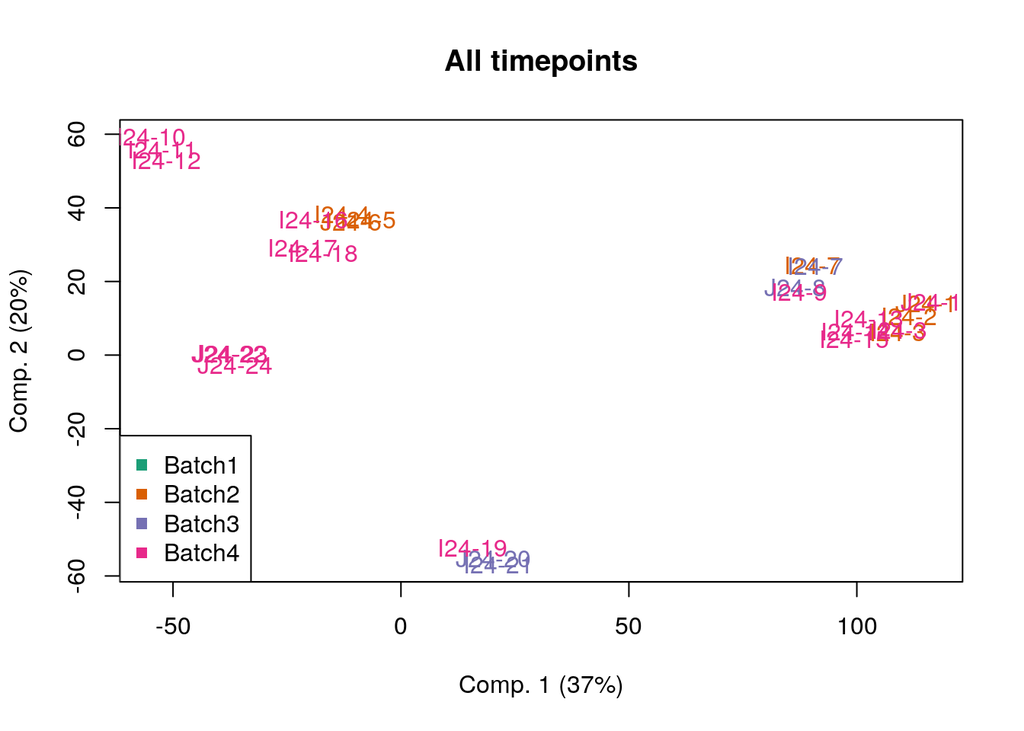

```r
t.sel <- samples$Timepoint == 24 & samples$Batch %in% c("P11554_2","P13406_1","P14066_1")
conds <- droplevels(conditions1[t.sel])
plot(pc$x[t.sel,1],
     pc$x[t.sel,2],
     xlab=paste("Comp. 1 (",percent[1],"%)",sep=""),
     ylab=paste("Comp. 2 (",percent[2],"%)",sep=""),
     type="n",
     main="All timepoints")

text(pc$x[t.sel,1],
     pc$x[t.sel,2],
     samples$SampleName[t.sel],
     col=pal[as.integer(samples$Batch)[t.sel]])

legend("bottomleft",col=pal[1:nlevels(samples$Batch)],
       pch=15,
       legend=c("Batch1","Batch2","Batch3","Batch4"))
```

```r
pander(samples[t.sel,][order(samples$SampleName[t.sel]),])
```

Table continues below

|  | SciLifeID | SampleName | Timepoint | Nutrition | AZD | Conditions |
| --- | --- | --- | --- | --- | --- | --- |
| **70** | P14066_140 | I24-10 | 24 | NP | AZD | 24_NP_AZD |
| **71** | P14066_141 | I24-11 | 24 | NP | AZD | 24_NP_AZD |
| **72** | P14066_142 | I24-12 | 24 | NP | AZD | 24_NP_AZD |
| **73** | P14066_143 | I24-13 | 24 | PKS | DMSO | 24_PKS_DMSO |
| **74** | P14066_144 | I24-14 | 24 | PKS | DMSO | 24_PKS_DMSO |
| **75** | P14066_145 | I24-15 | 24 | PKS | DMSO | 24_PKS_DMSO |
| **76** | P14066_146 | I24-16 | 24 | PKS | AZD | 24_PKS_AZD |
| **77** | P14066_147 | I24-17 | 24 | PKS | AZD | 24_PKS_AZD |
| **78** | P14066_148 | I24-18 | 24 | PKS | AZD | 24_PKS_AZD |
| **79** | P14066_149 | I24-19 | 24 | NS | DMSO | 24_NS_DMSO |
| **32** | P11554_232 | I24-2 | 24 | NPS | DMSO | 24_NPS_DMSO |
| **64** | P13406_105 | I24-21 | 24 | NS | DMSO | 24_NS_DMSO |
| **33** | P11554_233 | I24-3 | 24 | NPS | DMSO | 24_NPS_DMSO |
| **68** | P14066_133 | I24-3 | 24 | NPS | DMSO | 24_NPS_DMSO |
| **34** | P11554_234 | I24-4 | 24 | NPS | AZD | 24_NPS_AZD |
| **35** | P11554_235 | I24-5 | 24 | NPS | AZD | 24_NPS_AZD |
| **37** | P11554_237 | I24-7 | 24 | NP | DMSO | 24_NP_DMSO |
| **61** | P13406_102 | I24-7 | 24 | NP | DMSO | 24_NP_DMSO |
| **69** | P14066_139 | I24-9 | 24 | NP | DMSO | 24_NP_DMSO |
| **31** | P11554_231 | J24-1 | 24 | NPS | DMSO | 24_NPS_DMSO |
| **67** | P14066_131 | J24-1 | 24 | NPS | DMSO | 24_NPS_DMSO |
| **63** | P13406_104 | J24-20 | 24 | NS | DMSO | 24_NS_DMSO |
| **80** | P14066_152 | J24-22 | 24 | NS | AZD | 24_NS_AZD |
| **81** | P14066_153 | J24-23 | 24 | NS | AZD | 24_NS_AZD |
| **82** | P14066_154 | J24-24 | 24 | NS | AZD | 24_NS_AZD |
| **36** | P11554_236 | J24-6 | 24 | NPS | AZD | 24_NPS_AZD |
| **62** | P13406_103 | J24-8 | 24 | NP | DMSO | 24_NP_DMSO |

|  | Batch |
| --- | --- |
| **70** | P14066_1 |
| **71** | P14066_1 |
| **72** | P14066_1 |
| **73** | P14066_1 |
| **74** | P14066_1 |
| **75** | P14066_1 |
| **76** | P14066_1 |
| **77** | P14066_1 |
| **78** | P14066_1 |
| **79** | P14066_1 |
| **32** | P11554_2 |
| **64** | P13406_1 |
| **33** | P11554_2 |
| **68** | P14066_1 |
| **34** | P11554_2 |
| **35** | P11554_2 |
| **37** | P11554_2 |
| **61** | P13406_1 |
| **69** | P14066_1 |
| **31** | P11554_2 |
| **67** | P14066_1 |
| **63** | P13406_1 |
| **80** | P14066_1 |
| **81** | P14066_1 |
| **82** | P14066_1 |
| **36** | P11554_2 |
| **62** | P13406_1 |

```r
#norm_data <- read.csv("Tom-normalizedToT0-data-vst-blind.csv",row.names = 1)
#ssel <- samples$SciLifeID[samples$Timepoint %in% c(0,6) &
#                              samples$Nutrition %in% c("NPS","NS","T0") &
#                              substr(colnames(tx$counts),1,8) %in% c("P11554_2","P13406_1","P14066_1")]
#counts <- norm_data[,colnames(norm_data) %in% factor(ssel)]
#sel <- order(apply(log2(counts),1,sd),decreasing=TRUE)[1:1000]
#heatmap.2(log2(counts[sel,]+1),labRow = NA,trace = "none")
#
#ssel <- samples$SciLifeID[samples$Timepoint %in% c(0,6) &
#                              samples$Nutrition %in% c("NPS","NS") &
#                              substr(colnames(tx$counts),1,8) %in% c("P11554_2","P13406_1")]
#counts <- tx$counts[,substr(colnames(tx$counts),1,8) %in% c("P11554_2","P13406_1")]
#counts <- tx$counts[,colnames(tx$counts) %in% factor(ssel)]
#sel <- order(apply(log2(counts),1,sd),decreasing=TRUE)[1:1000]
#heatmap.2(log2(counts[sel,]+1),labRow = NA,trace = "none")









#zero <- samples$SciLifeID[samples$Nutrition == "T0"]
#count_zero <- tx$counts[,colnames(tx$counts) %in% factor(zero) &
#                                      substr(colnames(tx$counts),1,8) %in% c("P11554_2","P13406_1")]
#c <- apply(count_zero,1,mean)
#count_zero <- cbind(count_zero,average=apply(count_zero,1,mean))
#counts2 <- counts / c
#counts3 <- log2(counts2)
#count_zero <- count_zero / c
#sel <- order(apply(log2(counts2),1,sd),decreasing=TRUE)[1:1000]
#hmcol = colorRampPalette(brewer.pal(9, "RdBu"))(100)
#heatmap.2(log2(counts2[sel,]+1),
#          col = hmcol,
#          scale="row",
#          labRow = NA,
#          trace = "none")
#write.table(counts3,file="/mnt/picea/projects/arabidopsis/jhanson/arabidopsis-nutrition-TOR/analysis_Tom/log2_normalized_to_T0.csv")
```